# Reproducible research_project 1

Stanislas de Bazelaire

1/24/2021

# Introduction

It is now possible to collect a large amount of data about personal movement using activity monitoring devices such as a Fitbit, Nike Fuelband, or Jawbone Up. These type of devices are part of the **“quantified self”** movement – a group of enthusiasts who take measurements about themselves regularly to improve their health, to find patterns in their behavior, or because they are tech geeks. But these data remain under-utilized both because the raw data are hard to obtain and there is a lack of statistical methods and software for processing and interpreting the data.

This assignment makes use of data from a personal activity monitoring device. This device collects data at 5 minute intervals through out the day. The data consists of **two months of data from an anonymous individual collected during the months of October and November**, 2012 and include the number of steps taken in 5 minute intervals each day.

So let’s get started!

# Reading and processing the data set

## Reading the data

- Let’s set the working directory and use the “downloader” package to load the data:

```r
setwd("C:/Users/stanislas_bazelaire/Box/Stanislas_Bazelaire/Data science/Reproducible research")
library(downloader)
download("https://d396qusza40orc.cloudfront.net/repdata%2Fdata%2Factivity.zip", dest="zipped.zip", mode="wb")
unzip ("zipped.zip",exdir = "./unzipped")
activity<-read.csv("./unzipped/activity.csv",header=TRUE,sep=",")
```

## Formatting the data

- Let’s check the format of the date column:

```r
class(activity$date)
```

```
## [1] "character"
```

- Let’s convert it to a date format:

```r
library(lubridate)
activity$date<-ymd(activity$date)
```

- Let’s check whether this is now the case:

```r
class(activity$date)
```

```
## [1] "Date"
```

- Let’s now add two columns: one named “weekday” indicating the name of the weekday, and another one named “type” indicating whether this is the week or the weekend:

```r
activity$weekday<-weekdays(activity$date)
activity$type <- with(activity, ifelse(activity$weekday=="Saturday"|activity$weekday=="Sunday","weekend","week"))
```

- This is how the data looks like now:

```r
head(activity)
```

```
##   steps       date interval weekday type
## 1    NA 2012-10-01        0  Monday week
## 2    NA 2012-10-01        5  Monday week
## 3    NA 2012-10-01       10  Monday week
## 4    NA 2012-10-01       15  Monday week
## 5    NA 2012-10-01       20  Monday week
## 6    NA 2012-10-01       25  Monday week
```

## Missing values

Oups, there are missing values! How many?

- Let’s compute the proportion of missing values:

```r
incomplete<-sum(!complete.cases(activity$steps))
complete<-sum(complete.cases(activity$steps))
missingper<-incomplete/(incomplete+complete)*100
print(missingper)
```

```
## [1] 13.11475
```

So, for **13.1147541%** of the 5 min periods we do not have the number of steps!

- Let’s assign a value of zero when the value is missing:

```r
activity$steps[is.na(activity$steps)]<-0
```

- Let’s have a look at the data by plotting the histogram of the total number of steps made:
1. Let’s compute the total number of steps made each day:

```r
aggsum<-aggregate(activity$steps ~ activity$date, data=activity, sum)
names(aggsum)<-c("date","steps")
```

2. Let’s plot the corresponding histogram:

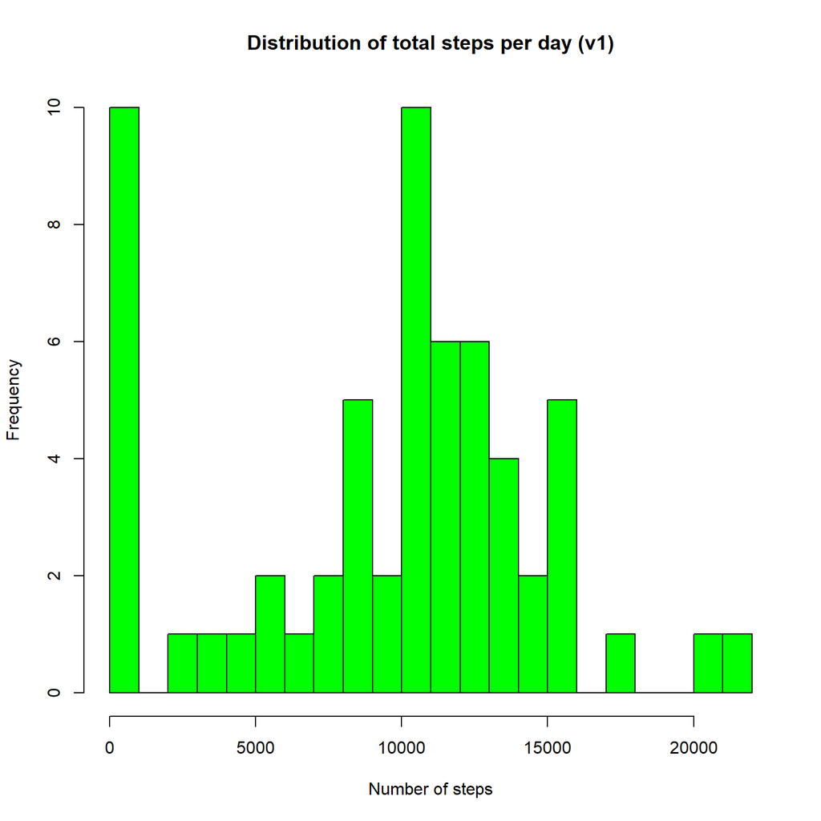

```r
hist(aggsum$steps,col="green",main="Distribution of total steps per day (v1)",breaks=20,xlab="Number of steps")
```

- Now, let’s implement a different approach to missing values whereby we replace them with the average number of steps observed on that specific 5 min interval. We proceed in two steps:
1. We compute the average number of steps per 5 min interval:

```r
aggint<-aggregate(activity$steps ~ activity$interval, data=activity, mean)
names(aggint)<-c("interval","avsteps")
```

2. We use the result above to fill missing values:

```r
activity<-read.csv("./unzipped/activity.csv",header=TRUE,sep=",")
activity$date<-ymd(activity$date)
activity$weekday<-weekdays(activity$date)
activity$type <- with(activity, ifelse(activity$weekday=="Saturday"|activity$weekday=="Sunday","weekend","week"))
N<-nrow(activity)
for (i in 1:N) {
  if (is.na(activity$steps[i])) {activity$steps[i]<- aggint$avsteps[aggint$interval==activity$interval[i]]
      }
}
```

- Let’s have a look at our new dataset:

```r
head(activity)
```

```
##        steps       date interval weekday type
## 1 1.49180328 2012-10-01        0  Monday week
## 2 0.29508197 2012-10-01        5  Monday week
## 3 0.11475410 2012-10-01       10  Monday week
## 4 0.13114754 2012-10-01       15  Monday week
## 5 0.06557377 2012-10-01       20  Monday week
## 6 1.81967213 2012-10-01       25  Monday week
```

- Let’s see the histogram based on this new dataset:

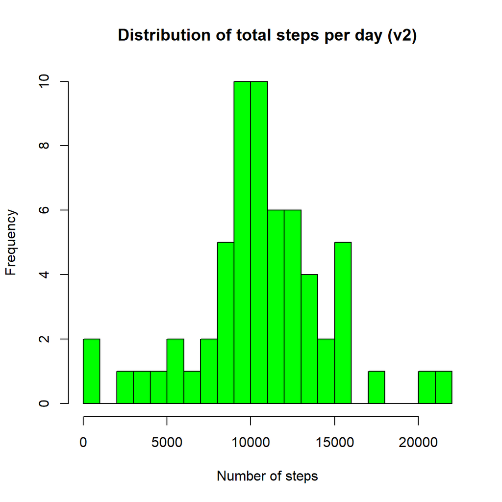

```r
aggsum<-aggregate(activity$steps ~ activity$date, data=activity, sum)
names(aggsum)<-c("date","steps")
hist(aggsum$steps,col="green",main="Distribution of total steps per day (v2)",breaks=20,xlab="Number of steps")
```

**The distribution of the total number of steps per day is now smoother!**

# Data analysis

Now that the data is clean, let’s extract a few results:

```r
t1<-aggregate(activity$steps ~ activity$weekday, data=activity, mean)
names(t1)<-c("weekday","mean")
t1$weekday<-factor(t1$weekday,levels=c("Monday","Tuesday","Wednesday","Thursday","Friday","Saturday","Sunday"))
t1<-t1[order(t1$weekday),]
print(t1)
```

```
##     weekday     mean
## 2    Monday 34.15604
## 6   Tuesday 31.07485
## 7 Wednesday 40.00009
## 5  Thursday 28.95688
## 1    Friday 40.59663
## 3  Saturday 42.14506
## 4    Sunday 41.36208
```

```r
t2<-aggregate(activity$steps ~ activity$weekday, data=activity, median)
names(t2)<-c("weekday","median")
t2$weekday<-factor(t2$weekday,levels=c("Monday","Tuesday","Wednesday","Thursday","Friday","Saturday","Sunday"))
t2<-t2[order(t2$weekday),]
print(t2)
```

```
##     weekday median
## 2    Monday      0
## 6   Tuesday      0
## 7 Wednesday      0
## 5  Thursday      0
## 1    Friday      0
## 3  Saturday      0
## 4    Sunday      0
```

- Let’s plot the **average number of steps made over the period per 5 min interval**:

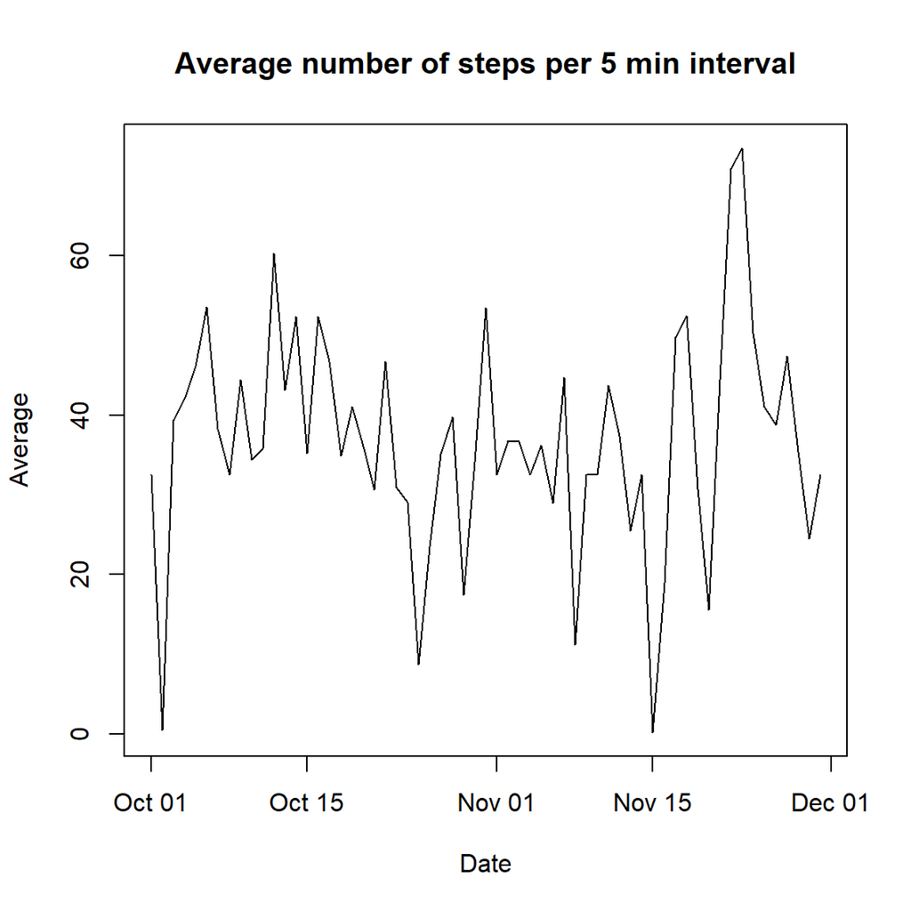

```r
aggmean<-aggregate(activity$steps ~ activity$date, data=activity, mean)
names(aggmean)<-c("date","meansteps")
plot(x=aggmean$date,y=aggmean$meansteps,type="l",xlab="Date",ylab="Average",main = "Average number of steps per 5 min interval")
```

- The **5-minute interval that, on average, contains the maximum number of steps**

```r
aggint<-aggregate(activity$steps ~ activity$interval, data=activity, mean)
names(aggint)<-c("interval","avsteps")
time<-aggint$interval[aggint$avsteps==max(aggint$avsteps)]
time<-time*1/100
print(time)
```

```
## [1] 8.35
```

i.e. at 8.35: wake-up!

- Let’s make a panel plot comparing the **average number of steps taken per 5-minute interval across weekdays and weekends**:

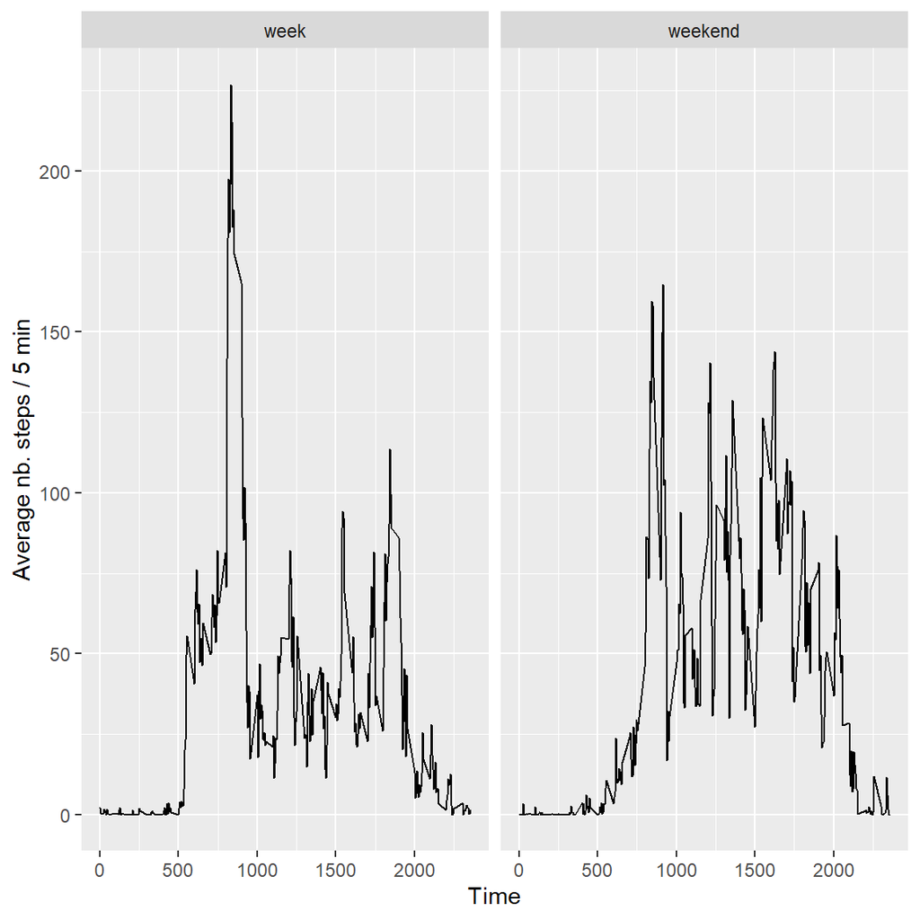

```r
aggday<-aggregate(activity$steps ~ activity$interval + activity$type,data=activity, mean)
names(aggday)<-c("interval","type","steps")
library(ggplot2)
plot<-ggplot(aggday,aes(x=aggday$interval,y=aggday$steps))+facet_grid(.~aggday$type)+geom_line()+labs(x="Time",y="Average nb. steps / 5 min")
print(plot)
```